# Obesity Comorbidity Analysis

Chloe Li

11/22/2016

# Introduction

This report documents data analytics process for obesity comorbidity analysis on data retrieved from NCBI. This is an assignment from Brown University’s the CIS Data Science Practice for assessing Chloe Li’s technical skills.

*NOTE: Select **Hide Code** to hide all R codes.*

The objective of tis assignment is to conduct a comorbidity analysis for obesity using NCBI’s PubMed database. The data was selected based on a date range of **2000 to 2012**, with a major MeSH descriptor of **“obesity”** and semantic types of **“Disease or Syndrome”**.

```r
#preparation
#clear environment if needed
rm(list = ls())
#set working directory
setwd('~/Documents/Dev_dataScienceProjects/BrownUniv/')
#install/reuqire libraries
if (!'pacman' %in% installed.packages()){
  install.packages('pacman')
}
pacman::p_load("ggplot2","dplyr", "rentrez","knitr","RCurl","plyr","tidyr","data.table")
#rentrez is the package in R provides an interface to the NCBI's EUtils API
```

# Methods

1. Data retrieval from PubMed.
2. Data processing on PubMed data
3. MeSH descriptors XML parsing and processing
4. Mapping MeSH descriptors to PubMed data
5. Data analysis

# Data Retrieval

In order to retreive data based on date range and keywords, a correct search query should be formulated. The package of R named “rentrez” allows R users to pull data from NCBI.

## PubMed Search

**entrez_db_summary()** shows summary of a certain database, in this case, **PubMed** database is used.

- Database summary: **PubMed**

```r
#show the database summary information
entrez_db_summary("pubmed")
```

```
 DbName: pubmed
 MenuName: PubMed
 Description: PubMed bibliographic record
 DbBuild: Build161128-2207m.5
 Count: 26706289
 LastUpdate: 2016/11/29 16:54
```

**entrez_db_searchable()** shows searchable fields under a certain database, users can decide which keywords should be put under which searchable field.

- List of **PubMed**’s *searchable fields* (below only shows **MAJR**)

```r
#Searchable fields for database 'pubmed'
searchField <- entrez_db_searchable("pubmed")
searchField$MAJR
```

```
 Name: MAJR
 FullName: MeSH Major Topic
 Description: MeSH terms of major importance to publication
 TermCount: 544935
 IsDate: N
 IsNumerical: N
 SingleToken: Y
 Hierarchy: Y
 IsHidden: N
```

- In order to form the PubMed/MEDLINE search for articles between 2000 and 2012 with obesity indicated as the major MeSH descriptor, elements below should be included in the query:
  - **MAJR** - MeSH terms of major importance to publication is used as searchable fields
  - **2000/01/01:2012/12/31[PDAT]** is date of publication/[PDAT]
  - **pubmed** is the database

Below shows the search result, which contains 59515 records and a web_history object; Here is the summary of search result:

```r
query <- "obesity[MAJR] AND 2000/01/01:2012/12/31[PDAT]"
obesity_search <- entrez_search(db="pubmed",
                        query,
                        retmode = "xml",
                        use_history = TRUE,
                        retmax=60000)
kable(summary(obesity_search))
```

|  | Length | Class | Mode |
| --- | --- | --- | --- |
| ids | 59515 | -none- | character |
| count | 1 | -none- | numeric |
| retmax | 1 | -none- | numeric |
| QueryTranslation | 1 | -none- | character |
| file | 1 | XMLInternalDocument | externalptr |
| web_history | 2 | web_history | list |

- A *web histroy* was returned as well, which NCBI created for users who deals with very large queries. With this *web history*, all records based on the search query were stored on NCBI server waiting for further usage.

```r
obesity_search$web_history
```

```
Web history object (QueryKey = 1, WebEnv = NCID_1_44382...)
```

- **The formulation of the PubMed search is shown below:**

```r
obesity_search$QueryTranslation
```

```
[1] "\"obesity\"[MeSH Major Topic] AND 2000/01/01[PDAT] : 2012/12/31[PDAT]"
```

In order to make sure this search result match with the number of records on NCBI. The same searching criteria were used on NCBI website manually, and the result is shown below:

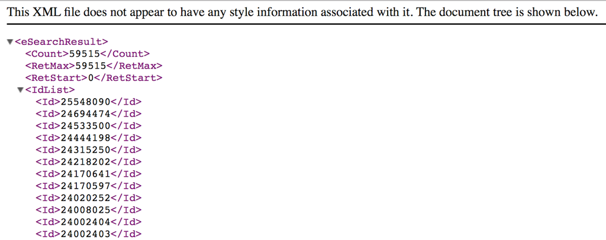

## Fetch Data

Based on the search query, all records that matched with the criteria were found and all IDs were returned. Those IDs or the web history could be used to fetch all records from NCBI. However, NCBI only allows users to pull 10,000 records at once. Therefore, a web history needs to be used to save the search result in the server so that all 59,515 records can be pulled from multiple batches.

- Obtained PubMed/MEDLINE records (in MEDLINE or XML format) for the formulated search using NCBI E-Utilities
- Extracted “pmid”,“authors”,“year”,“articletitle”,“meshHeadings” from all records and stored values into a data frame.

```r
#fetch all records from the formulated search
source('./batchFetch_Fun.R')
#this returns a data frame with extracted information from all records
dt_sum <- batchFetch(obesity_search)
#function code will be shown at the end of this report
#save dt_sum in local so don't need to run every time
#write.csv(dt_sum, "obesity_SumTable.csv")
#dt_sum <- read.csv("obesity_SumTable.csv")
#dt_sum$X <- NULL
```

- Sample of the data frame

```r
kable(dt_sum[1:3,])
```

| pmid | authors | year | articletitle | meshHeadings |
| --- | --- | --- | --- | --- |
| 25548090 | So ES\|Yoo KS | 2015 | Waist circumference cutoff points for central obesity in the Korean elderly population. | Age Distribution\|Aged\|Aged, 80 and over\|Female\|Humans\|Logistic Models\|Male\|Metabolic Syndrome X\|Nutrition Surveys\|Obesity, Abdominal\|ROC Curve\|Republic of Korea\|Risk Factors\|Sex Distribut… |
| 24694474 | Sakurai M\|Nakamura K\|Miura K\|Yoshita K\|Takamura T\|Nagasawa SY\|Morikawa Y\|Ishizaki M\|Kido T\|Naruse Y\|Nakashima M\|Nogawa K\|Suwazono Y\|Nakagawa H | 2014 | Association between a serum thyroid-stimulating hormone concentration within the normal range and indices of obesity in Japanese men and women. | Adult\|Biomarkers\|Body Mass Index\|Body Weight\|Cross-Sectional Studies\|Female\|Humans\|Incidence\|Japan\|Male\|Middle Aged\|Obesity\|Prevalence\|Prognosis\|Reference Values\|Surveys and Questionnai… |
| 24533500 | Drenowatz C\|Kobel S\|Kettner S\|Kesztyüs D\|Steinacker JM | 2014 | Interaction of sedentary behaviour, sports participation and fitness with weight status in elementary school children. | Analysis of Variance\|Body Mass Index\|Child\|Exercise\|Female\|Germany\|Humans\|Logistic Models\|Male\|Odds Ratio\|Overweight\|Pediatric Obesity\|Physical Fitness\|Sedentary Lifestyle\|Sports\|Survey… |

## Data Processing

To prepare the data for further analysis, two variables *authors* and *meshHeadings* should be re formatted since there are multiple values in one record for both variables. *authors* and *meshHeadings* variables should be unlisted so that each row represents an unique record of meshHeadings and authors with pmid, publication year and article title.

```r
source('./unlistDT_Fun.R')
#return a data frame of 5 variables with each cell contains only single value
dt_tidy <- unlistDT(dt_sum)
#write.csv(dt_tidy, "tidy_obesitySearch.csv")
```

- Sample of the data frame

```r
kable(dt_tidy[1:5,])
```

| pmid | authors | meshHeadings | articletitle | year |
| --- | --- | --- | --- | --- |
| 10580166 | Bakker SJ | Animals | Cytosolic triglycerides and oxidative stress in central obesity: the missing link between excessive atherosclerosis, endothelial dysfunction, and beta-cell failure? | 2000 |
| 10580166 | IJzerman RG | Arteriosclerosis | Cytosolic triglycerides and oxidative stress in central obesity: the missing link between excessive atherosclerosis, endothelial dysfunction, and beta-cell failure? | 2000 |
| 10580166 | Teerlink T | Cytosol | Cytosolic triglycerides and oxidative stress in central obesity: the missing link between excessive atherosclerosis, endothelial dysfunction, and beta-cell failure? | 2000 |
| 10580166 | Westerhoff HV | Endothelium, Vascular | Cytosolic triglycerides and oxidative stress in central obesity: the missing link between excessive atherosclerosis, endothelial dysfunction, and beta-cell failure? | 2000 |
| 10580166 | Gans RO | Humans | Cytosolic triglycerides and oxidative stress in central obesity: the missing link between excessive atherosclerosis, endothelial dysfunction, and beta-cell failure? | 2000 |

# Mapping

- Goal: create mapping of MeSH descriptors to semantic types using the MeSH Vocabulary file (desc2015.xml) and identify descriptors with type **Disease or Syndrome**
- Link to MeSH Descriptors XML file: _ftp://nlmpubs.nlm.nih.gov/online/mesh/2015/desc2015.xml_

## Dictionary

Parse MeSH descriptors XML file:

```r
#download XML file - 2015 MeSH descriptor
MeSHdescriptor <- XML::xmlParse("ftp://nlmpubs.nlm.nih.gov/online/mesh/2015/desc2015.xml")
#meshList <- xmlToList(MeSHdescriptor)
```

- In order to map MeSH descriptors to semantic types, **DescriptorName** and **SemanticTypeName** were extracted from the XML file above for the purpose of creating a dictionary, which later was used to link the MeSH descriptor from PubMed search.

```r
#extract value from xml
source("./ExtractDict_Fun.R")
dt_MeshDict <- ExtractDict(MeSHdescriptor)
```

Summary of the dictionary before cleaning:

```r
kable(dt_MeshDict[1:5,])
```

| meshHeadings | SemanticTypeName |
| --- | --- |
| Calcimycin\|Anti-Bacterial Agents\|Calcium Ionophores | Organic Chemical\|Antibiotic\|Organic Chemical\|Antibiotic |
| Temefos\|Insecticides | Organophosphorus Compound\|Hazardous or Poisonous Substance\|Organophosphorus Compound\|Hazardous or Poisonous Substance\|Organophosphorus Compound\|Hazardous or Poisonous Substance |
| Abattoirs | Manufactured Object |
| Abbreviations as Topic | Intellectual Product\|Intellectual Product |
| Abdomen\|Abdomen\|Abdominal Injuries\|Abdomen\|Radiography, Abdominal | Body Location or Region |

The above record contains variables that have multiple values per row/record since one meshHeading might associate with multiple SemanticTypeName. In order to get the data ready for mapping, the data frame needs to be transformed and each cell should be unlisted so that each cell contains only single value.

```r
#unlist variables (tidy)
source("./MeshDict_Fun.R")
tidy_Dict <- MeshDict(dt_MeshDict)
#reorder
tidy_Dict <- dplyr::arrange(tidy_Dict, SemanticTypeName)
```

Sample of the MeSH-SemanticType dictionary

```r
kable(tidy_Dict[1:10,])
```

| meshHeadings | SemanticTypeName |
| --- | --- |
| Airway Remodeling | Acquired Abnormality |
| Amputation Stumps | Acquired Abnormality |
| Amyloidosis | Acquired Abnormality |
| Aneurysm, Dissecting | Acquired Abnormality |
| Ankylosis | Acquired Abnormality |
| Anti-Ulcer Agents | Acquired Abnormality |
| Aphakia, Postcataract | Acquired Abnormality |
| Arachnoid Cysts | Acquired Abnormality |
| Arcus Senilis | Acquired Abnormality |
| Biofilms | Acquired Abnormality |

## Mapping

```r
#save the dataframe in case
dt_PubMed <- dt_tidy
#merge/VLOOKUP to map the semantictype to dt_PubMed
dt_Mapped <- merge(dt_PubMed, tidy_Dict, by="meshHeadings",all.x=TRUE)
#rearrange columns and rows
dt_Mapped <- dplyr::select(dt_Mapped, pmid,meshHeadings,SemanticTypeName,articletitle,authors,year)
dt_Mapped <- dplyr::arrange(dt_Mapped, SemanticTypeName)
```

Sample record of mapped PubMed search:

```r
kable(dt_Mapped[1:5,])
```

| pmid | meshHeadings | SemanticTypeName | articletitle | authors | year |
| --- | --- | --- | --- | --- | --- |
| 21453798 | Airway Remodeling | Acquired Abnormality | Impact of obesity on airway and lung parenchyma remodeling in experimental chronic allergic asthma. | Silva AL | 2011 |
| 17608272 | Amyloidosis | Acquired Abnormality | Biliopancreatic diversion in a renal transplant patient. | Fernández-Escalante C | 2007 |
| 19825338 | Amyloidosis | Acquired Abnormality | Renal AA amyloidosis secondary to morbid obesity? | Martin M | 2009 |
| 18313627 | Amyloidosis | Acquired Abnormality | Heart failure with preserved ejection fraction: hypertension, diabetes, obesity/sleep apnea, and hypertrophic and infiltrative cardiomyopathy. | Desai A | 2008 |
| 17608272 | Amyloidosis | Acquired Abnormality | Biliopancreatic diversion in a renal transplant patient. | López Deogracias M | 2007 |

## Data Processing

- Remove meshHeadings == “Obesity”
- Select only SemanticTypeName == ‘Disease or Syndrome’
- Data is ready for analysis:

```r
#remove meshHeadings that are 'Obesity'
dt_filter <- dplyr::filter(dt_Mapped, meshHeadings != 'Obesity')
#select only 'Disease or Syndrome' as SemanticTypeName
dt_filter <- dplyr::filter(dt_filter, SemanticTypeName == 'Disease or Syndrome')
#check if neccessary
#str(dt_filter)
kable(dt_filter[1:5,])
```

| pmid | meshHeadings | SemanticTypeName | articletitle | authors | year |
| --- | --- | --- | --- | --- | --- |
| 21829000 | 22q11 Deletion Syndrome | Disease or Syndrome | Auxological evaluation in patients with a 22q11.2 microdeletion syndrome: normal prevalence of obesity and neonatal length and gender influence on body mass index evolution. | Reynaud R | 2011 |
| 20098742 | 3-Oxo-5-alpha-Steroid 4-Dehydrogenase | Disease or Syndrome | Effects of proportions of dietary macronutrients on glucocorticoid metabolism in diet-induced obesity in rats. | Stimson RH | 2010 |
| 10650936 | 3-Oxo-5-alpha-Steroid 4-Dehydrogenase | Disease or Syndrome | Understanding the role of glucocorticoids in obesity: tissue-specific alterations of corticosterone metabolism in obese Zucker rats. | Jones GC | 2000 |
| 15550507 | 3-Oxo-5-alpha-Steroid 4-Dehydrogenase | Disease or Syndrome | Reduced adipose glucocorticoid reactivation and increased hepatic glucocorticoid clearance as an early adaptation to high-fat feeding in Wistar rats. | Livingstone DE | 2005 |
| 20585779 | Abdominal Abscess | Disease or Syndrome | CT-guided percutaneous drainage of infected collections due to gastric leak after sleeve gastrectomy for morbid obesity: initial experience. | Kelogrigoris M | 2011 |

# Analysis

Goal: Use a statistical or modeling approach to identify and to rank comorbidities for obesity based on publications that share MeSH descriptors for multiple disease or syndrome.

## Trend

- Let’s take a look at the trend on publications about obesity from 2000-2012:

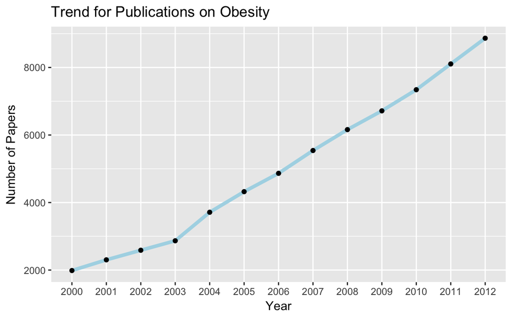

As the line chart above shown, the number of publications with **Obesity** as major MeSH topic was increasing over the period of 2000 to 2012. Over time, the trend held consistent increase rate but from 2003 to 2004, it seemed that there was a large increase on the number of pulications on obesity.

## Ranking

- Here is a sample record of unique **pmid** count on **meshHeadings**:

```r
#group by meshHeadings and count number records for each MeSH
meSH_count <- setDT(dt_filter)[, .(count = uniqueN(pmid)), by = meshHeadings]
meSH_count <- as.data.frame(meSH_count)
#rarrange
meSH_count <- dplyr::arrange(meSH_count, -count)
meSH_count <- dplyr::select(meSH_count, meshHeadings,Count = count)
kable(meSH_count[1:10,])
```

| meshHeadings | Count |
| --- | --- |
| Insulin Resistance | 5387 |
| Diabetes Mellitus, Type 2 | 4669 |
| Insulin | 4238 |
| Life Style | 3047 |
| Cardiovascular Diseases | 2976 |
| Metabolic Syndrome X | 2900 |
| Hypertension | 2676 |
| Diabetes Mellitus | 1995 |
| Health Behavior | 1549 |
| Feeding Behavior | 1420 |

- Histogram of top 25 disease or syndrome:

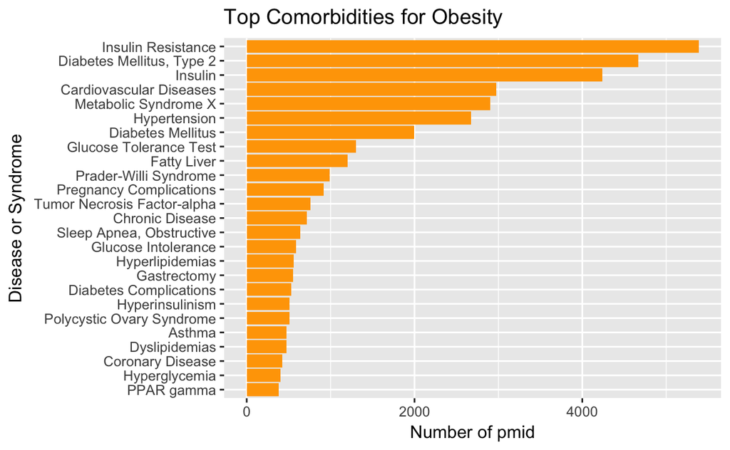

```r
#subset the top 25 records
Top25 <- meSH_count[1:29,]
Top25 <- dplyr::filter(Top25, meshHeadings != "Life Style"& meshHeadings != "Health Behavior" & meshHeadings != "Feeding Behavior"&meshHeadings != "Quality of Life")

ggplot(Top25) +
    geom_bar(aes(x=reorder(meshHeadings, Count),y=Count),stat="identity",fill = "orange") +                               #theme(axis.text.x = element_text(angle = 90, hjust = 1)) +
                              ggtitle("Top Comorbidities for Obesity") +
                              xlab("Disease or Syndrome") +
                              ylab("Number of pmid") +
                              coord_flip()#+
```

# Conclusions

The most common complication of obesity is **Insulin Resistance** syndrome while the second most common complication is **Diabetes Mellitus, Type 2**. Among top most comorbidities of obesity, most of diseases or syndromes fall under the category of metabolic syndrome. Moreover, according to the trend of number of publications on obesity, it was certain that many researches and discussions were on obesity.